# Tutorial: Single Cell RNA-Seq Analysis of PBMC's from a healthy human Vs an Uveitis patient, using SCassist - an AI-Based Workflow Assistant

## 1. Quality Control

This document takes the cellranger count data for two samples (a healthy control and a Uveitis patient) and performs standard single cell rnaseq analysis, using the SCassist package.

```r
# Install hdf5 library if its not already installed
#sudo apt-get install libhdf5-dev or brew install hdf5
#install.packages("hdf5r")

# Load below libraries
library(Seurat)
library(ggplot2)
library(plotly)
library(tidyverse)
library(cowplot)
library(scProportionTest)
library(rollama)
library(SCassist)
library(httr)
library(jsonlite)
library(dplyr)
```

### 1.1. Data setup

```r
# Set the input, output paths
setwd("/singlecellassistant")
datapath="exampleData"
outputpath="/singlecellassistant/exampleOutput_G/BCRUV/"
sampleinfopath="/singlecellassistant/exampleData/BCRUV/BCRUV_SampleInformation.tab"

# Load RData for example dataset
load("/singlecellassistant/exampleOutput_G/BCRUV/bcruv_G_new.RData")

# Read sample information file
sampleinformation=read.csv(sampleinfopath,sep="\t")
head(sampleinformation)
```

```
##                RunID                                  file_name
## 1 HVHL7DRXX_19022128 HVHL7DRXX_19022128_S3_L001_R1_001.fastq.gz
## 2 HVHL7DRXX_19022128 HVHL7DRXX_19022128_S3_L001_R2_001.fastq.gz
## 3 HVHL7DRXX_19022126 HVHL7DRXX_19022126_S2_L001_R1_001.fastq.gz
## 4 HVHL7DRXX_19022126 HVHL7DRXX_19022126_S2_L001_R2_001.fastq.gz
## 5 HVHL7DRXX_19022124 HVHL7DRXX_19022124_S4_L001_R1_001.fastq.gz
## 6 HVHL7DRXX_19022124 HVHL7DRXX_19022124_S4_L001_R2_001.fastq.gz
##                                  folder_location_in_biowulf submitted_name
## 1 /data/../TotalSeq/RawData/201230_INGENS_0255_B_HVHL7DRXX/     NS3R189BTS
## 2 /data/../TotalSeq/RawData/201230_INGENS_0255_B_HVHL7DRXX/     NS3R189BTS
## 3 /data/../TotalSeq/RawData/201230_INGENS_0255_B_HVHL7DRXX/     NS3R189BTS
## 4 /data/../TotalSeq/RawData/201230_INGENS_0255_B_HVHL7DRXX/     NS3R189BTS
## 5 /data/../TotalSeq/RawData/201230_INGENS_0255_B_HVHL7DRXX/     NS3R189BTS
## 6 /data/../TotalSeq/RawData/201230_INGENS_0255_B_HVHL7DRXX/     NS3R189BTS
##       project   machine_type pcnt_optical_duplicates  clusters read_length
```

[output cut: 27 more lines]

```r
# Specify samples for analysis.
samples=c("NS3R189BTS","NS7R65BBTS")

# Read the data file
NS3R189BTS <- Read10X_h5(file.path("/BCRUV/BCRUV_NS3R189BTS_filtered_feature_bc_matrix.h5"), use.names = T)

NS7R65BBTS <- Read10X_h5(file.path("/BCRUV/BCRUV_NS7R65BBTS_filtered_feature_bc_matrix.h5"), use.names = T)

# Add sample names to columnnames
colnames(NS3R189BTS$`Gene Expression`) <- paste(sapply(strsplit(colnames(NS3R189BTS$`Gene Expression`),split="-"),'[[',1L),"NS3R189BTS",sep="-")

colnames(NS7R65BBTS$`Gene Expression`) <- paste(sapply(strsplit(colnames(NS7R65BBTS$`Gene Expression`),split="-"),'[[',1L),"NS7R65BBTS",sep="-")

# Create a Seurat data object from the gex matrix
NS3R189BTS <- CreateSeuratObject(counts = NS3R189BTS[["Gene Expression"]], names.field = 2,names.delim = "\\-")

NS7R65BBTS <- CreateSeuratObject(counts = NS7R65BBTS[["Gene Expression"]], names.field = 2,names.delim = "\\-")

# Merge seurat objects
allsamples <- merge(NS3R189BTS, NS7R65BBTS, project = "UV")
allsamples
```

```
## An object of class Seurat
## 36601 features across 39090 samples within 1 assay
## Active assay: RNA (36601 features, 0 variable features)
##  2 layers present: counts.1, counts.2
```

```r
head(allsamples)
```

```
##                             orig.ident nCount_RNA nFeature_RNA
## AAACCCACAAGTCATC-NS3R189BTS NS3R189BTS       2431         1431
## AAACCCACACTGGAAG-NS3R189BTS NS3R189BTS       2676         1078
## AAACCCACAGCACACC-NS3R189BTS NS3R189BTS       3394         1760
## AAACCCACAGGAGGAG-NS3R189BTS NS3R189BTS       2160         1279
## AAACCCACATGACGTT-NS3R189BTS NS3R189BTS       2329         1271
## AAACCCAGTAGTTACC-NS3R189BTS NS3R189BTS       5362         2261
## AAACCCAGTCCAAATC-NS3R189BTS NS3R189BTS       7926         2660
## AAACCCAGTCCATACA-NS3R189BTS NS3R189BTS       2239         1283
## AAACCCAGTGAGTTTC-NS3R189BTS NS3R189BTS       2339         1291
## AAACCCAGTTCTTAGG-NS3R189BTS NS3R189BTS       3537         1608
```

```r
table(Idents(allsamples))
```

```
##
## NS3R189BTS NS7R65BBTS
##      24790      14300
```

```r
# Merge counts data
allsamples = JoinLayers(allsamples)
```

### 1.2. Quality Analysis

This part of the workflow uses SCassist_analyze_quality(), to identify potential filtering cutoff values. SCassist provides the recommendation based on the summary statistics and the quantile statistic of the data.

```r
# Generate Percent mito for each of the cells
allsamples$percent.mito <- PercentageFeatureSet(allsamples, pattern = "^MT-")
summary(allsamples$percent.mito)
```

```
##    Min. 1st Qu.  Median    Mean 3rd Qu.    Max.
##   0.000   2.300   3.517   4.084   5.197  86.180
```

```r
head(allsamples)
```

```
##                             orig.ident nCount_RNA nFeature_RNA percent.mito
## AAACCCACAAGTCATC-NS3R189BTS NS3R189BTS       2431         1431    4.1135335
## AAACCCACACTGGAAG-NS3R189BTS NS3R189BTS       2676         1078    0.8221226
## AAACCCACAGCACACC-NS3R189BTS NS3R189BTS       3394         1760    5.1856217
## AAACCCACAGGAGGAG-NS3R189BTS NS3R189BTS       2160         1279    6.5277778
## AAACCCACATGACGTT-NS3R189BTS NS3R189BTS       2329         1271    4.3795620
## AAACCCAGTAGTTACC-NS3R189BTS NS3R189BTS       5362         2261    3.8418501
## AAACCCAGTCCAAATC-NS3R189BTS NS3R189BTS       7926         2660    4.6177139
## AAACCCAGTCCATACA-NS3R189BTS NS3R189BTS       2239         1283    5.0468959
## AAACCCAGTGAGTTTC-NS3R189BTS NS3R189BTS       2339         1291    5.3014109
## AAACCCAGTTCTTAGG-NS3R189BTS NS3R189BTS       3537         1608    2.2900763
```

```r
# Generate Percent ribo for each of the cells
allsamples$percent.ribo <- PercentageFeatureSet(allsamples, pattern = "^RP[SL]")
summary(allsamples$percent.ribo)
```

```
##    Min. 1st Qu.  Median    Mean 3rd Qu.    Max.
##  0.5956 20.4335 25.8115 26.1630 32.7232 68.7378
```

```r
head(allsamples)
```

```
##                             orig.ident nCount_RNA nFeature_RNA percent.mito
## AAACCCACAAGTCATC-NS3R189BTS NS3R189BTS       2431         1431    4.1135335
## AAACCCACACTGGAAG-NS3R189BTS NS3R189BTS       2676         1078    0.8221226
## AAACCCACAGCACACC-NS3R189BTS NS3R189BTS       3394         1760    5.1856217
## AAACCCACAGGAGGAG-NS3R189BTS NS3R189BTS       2160         1279    6.5277778
## AAACCCACATGACGTT-NS3R189BTS NS3R189BTS       2329         1271    4.3795620
## AAACCCAGTAGTTACC-NS3R189BTS NS3R189BTS       5362         2261    3.8418501
## AAACCCAGTCCAAATC-NS3R189BTS NS3R189BTS       7926         2660    4.6177139
## AAACCCAGTCCATACA-NS3R189BTS NS3R189BTS       2239         1283    5.0468959
## AAACCCAGTGAGTTTC-NS3R189BTS NS3R189BTS       2339         1291    5.3014109
## AAACCCAGTTCTTAGG-NS3R189BTS NS3R189BTS       3537         1608    2.2900763
##                             percent.ribo
## AAACCCACAAGTCATC-NS3R189BTS    18.510901
## AAACCCACACTGGAAG-NS3R189BTS    42.526158
## AAACCCACAGCACACC-NS3R189BTS    19.151444
## AAACCCACAGGAGGAG-NS3R189BTS     8.842593
## AAACCCACATGACGTT-NS3R189BTS    18.978102
## AAACCCAGTAGTTACC-NS3R189BTS    18.985453
## AAACCCAGTCCAAATC-NS3R189BTS    30.052990
## AAACCCAGTCCATACA-NS3R189BTS    19.830281
## AAACCCAGTGAGTTTC-NS3R189BTS    21.675930
## AAACCCAGTTCTTAGG-NS3R189BTS    23.353124
```

```r
# Generate Percent hemoglobin for each of the cells
allsamples$percent.hb <- PercentageFeatureSet(allsamples, pattern = "^HB[^(P)]")
summary(allsamples$percent.hb)
```

```
##     Min.  1st Qu.   Median     Mean  3rd Qu.     Max.
##  0.00000  0.00000  0.00000  0.07317  0.00000 96.37250
```

```r
head(allsamples)
```

```
##                             orig.ident nCount_RNA nFeature_RNA percent.mito
## AAACCCACAAGTCATC-NS3R189BTS NS3R189BTS       2431         1431    4.1135335
## AAACCCACACTGGAAG-NS3R189BTS NS3R189BTS       2676         1078    0.8221226
## AAACCCACAGCACACC-NS3R189BTS NS3R189BTS       3394         1760    5.1856217
## AAACCCACAGGAGGAG-NS3R189BTS NS3R189BTS       2160         1279    6.5277778
## AAACCCACATGACGTT-NS3R189BTS NS3R189BTS       2329         1271    4.3795620
## AAACCCAGTAGTTACC-NS3R189BTS NS3R189BTS       5362         2261    3.8418501
## AAACCCAGTCCAAATC-NS3R189BTS NS3R189BTS       7926         2660    4.6177139
## AAACCCAGTCCATACA-NS3R189BTS NS3R189BTS       2239         1283    5.0468959
## AAACCCAGTGAGTTTC-NS3R189BTS NS3R189BTS       2339         1291    5.3014109
## AAACCCAGTTCTTAGG-NS3R189BTS NS3R189BTS       3537         1608    2.2900763
##                             percent.ribo percent.hb
## AAACCCACAAGTCATC-NS3R189BTS    18.510901 0.00000000
## AAACCCACACTGGAAG-NS3R189BTS    42.526158 0.00000000
## AAACCCACAGCACACC-NS3R189BTS    19.151444 0.00000000
## AAACCCACAGGAGGAG-NS3R189BTS     8.842593 0.00000000
## AAACCCACATGACGTT-NS3R189BTS    18.978102 0.04293688
## AAACCCAGTAGTTACC-NS3R189BTS    18.985453 0.01864976
## AAACCCAGTCCAAATC-NS3R189BTS    30.052990 0.02523341
## AAACCCAGTCCATACA-NS3R189BTS    19.830281 0.04466280
## AAACCCAGTGAGTTTC-NS3R189BTS    21.675930 0.00000000
## AAACCCAGTTCTTAGG-NS3R189BTS    23.353124 0.00000000
```

```r
# Check the total number of cells in this experiment
table(allsamples$orig.ident)
```

```
##
## NS3R189BTS NS7R65BBTS
##      24790      14300
```

```r
api_key_file = "/singlecellassistant/api_keys.txt"

# Analyze quality of the cells using SCassist
allsamplesquality <- SCassist_analyze_quality("allsamples", percent_mt = "percent.mito", percent_ribo = "percent.ribo", percent_hb = "percent.hb", api_key_file = api_key_file, llm_server="google")
```

```
## Based on the data summary, below are my recommendations for the quality filtering of the data:
##
## **nCount_RNA:**
##
## * **Lower Cutoff:** 1000
## * **Upper Cutoff:** 15000
##
## **Rationale:** The 5th percentile suggests a lower limit of 1283, but considering the minimum value of 500, a lower cutoff of 1000 might be more appropriate to avoid removing potentially valid cells with low counts. The 95th percentile suggests an upper limit of 9600.55, but considering the maxim…
##
## **nFeature_RNA:**
##
## * **Lower Cutoff:** 800
## * **Upper Cutoff:** 4000
##
## **Rationale:** The 5th percentile suggests a lower limit of 780, but considering the minimum value of 46, a lower cutoff of 800 might be more appropriate to avoid removing potentially valid cells with low feature counts. The 95th percentile suggests an upper limit of 3069, but considering the max…
##
## **percent.mito:**
##
## * **Upper Cutoff:** 10
##
## **Rationale:** The 95th percentile suggests an upper limit of 8.68, but considering the maximum value of 86.18, an upper cutoff of 10 seems more reasonable to remove cells with extremely high mitochondrial content while retaining cells with moderate mitochondrial expression.
##
## **percent.ribo:**
##
## * **Upper Cutoff:** 50
##
## **Rationale:** The 95th percentile suggests an upper limit of 41.89, but considering the maximum value of 68.74, an upper cutoff of 50 seems more reasonable to remove cells with extremely high ribosomal content while retaining cells with moderate ribosomal expression.
##
## **percent.hb:**
##
## * **Upper Cutoff:** 0.1
##
## **Rationale:** The 95th percentile suggests an upper limit of 0.0499, but considering the maximum value of 96.37, an upper cutoff of 0.1 seems more reasonable to remove cells with extremely high hemoglobin content while retaining cells with moderate hemoglobin expression.
##
## **Important Note:** These are just recommendations based on the provided data. It is crucial to test a range of values around these recommendations to determine the optimal cutoffs for your specific dataset and analysis goals. Visualizing the distributions of each metric can help in making inform…
```

```r
# The SCassist recommendation is also stored in "allsamplesquality"
#cat(allsamplesquality)
```

### 1.3. Quality Filtering

Here we use the SCassist recommended QC cutoff values obtained in the previous step to filter and visualize the before and after QC data.

```r
# Filter data based on SCassists recommendation
allsamplesgood <- subset(allsamples, subset =  nCount_RNA > 1000 & nCount_RNA < 15000 & nFeature_RNA > 800 & nFeature_RNA < 4000 & percent.mito < 10 & percent.ribo < 50 & percent.hb < 0.1)

# Counts before filtering
table(allsamples$orig.ident)
```

```
##
## NS3R189BTS NS7R65BBTS
##      24790      14300
```

```r
# Counts after filtering
table(allsamplesgood$orig.ident)
```

```
##
## NS3R189BTS NS7R65BBTS
##      22195      12772
```

### 1.4. Add metadata

```r
# Assign sample types
allsamples$type <- plyr::mapvalues(
  x = allsamples$orig.ident,
  from = sampleinformation$submitted_name,
  to = sampleinformation$SampleType
)

head(allsamples)
```

```
##                             orig.ident nCount_RNA nFeature_RNA percent.mito
## AAACCCACAAGTCATC-NS3R189BTS NS3R189BTS       2431         1431    4.1135335
## AAACCCACACTGGAAG-NS3R189BTS NS3R189BTS       2676         1078    0.8221226
## AAACCCACAGCACACC-NS3R189BTS NS3R189BTS       3394         1760    5.1856217
## AAACCCACAGGAGGAG-NS3R189BTS NS3R189BTS       2160         1279    6.5277778
## AAACCCACATGACGTT-NS3R189BTS NS3R189BTS       2329         1271    4.3795620
## AAACCCAGTAGTTACC-NS3R189BTS NS3R189BTS       5362         2261    3.8418501
## AAACCCAGTCCAAATC-NS3R189BTS NS3R189BTS       7926         2660    4.6177139
## AAACCCAGTCCATACA-NS3R189BTS NS3R189BTS       2239         1283    5.0468959
## AAACCCAGTGAGTTTC-NS3R189BTS NS3R189BTS       2339         1291    5.3014109
## AAACCCAGTTCTTAGG-NS3R189BTS NS3R189BTS       3537         1608    2.2900763
##                             percent.ribo percent.hb type
## AAACCCACAAGTCATC-NS3R189BTS    18.510901 0.00000000   HC
## AAACCCACACTGGAAG-NS3R189BTS    42.526158 0.00000000   HC
## AAACCCACAGCACACC-NS3R189BTS    19.151444 0.00000000   HC
## AAACCCACAGGAGGAG-NS3R189BTS     8.842593 0.00000000   HC
## AAACCCACATGACGTT-NS3R189BTS    18.978102 0.04293688   HC
## AAACCCAGTAGTTACC-NS3R189BTS    18.985453 0.01864976   HC
## AAACCCAGTCCAAATC-NS3R189BTS    30.052990 0.02523341   HC
## AAACCCAGTCCATACA-NS3R189BTS    19.830281 0.04466280   HC
## AAACCCAGTGAGTTTC-NS3R189BTS    21.675930 0.00000000   HC
## AAACCCAGTTCTTAGG-NS3R189BTS    23.353124 0.00000000   HC
```

```r
allsamplesgood$type <- plyr::mapvalues(
  x = allsamplesgood$orig.ident,
  from = sampleinformation$submitted_name,
  to = sampleinformation$SampleType
)

head(allsamplesgood)
```

```
##                             orig.ident nCount_RNA nFeature_RNA percent.mito
## AAACCCACAAGTCATC-NS3R189BTS NS3R189BTS       2431         1431    4.1135335
## AAACCCACACTGGAAG-NS3R189BTS NS3R189BTS       2676         1078    0.8221226
## AAACCCACAGCACACC-NS3R189BTS NS3R189BTS       3394         1760    5.1856217
## AAACCCACAGGAGGAG-NS3R189BTS NS3R189BTS       2160         1279    6.5277778
## AAACCCACATGACGTT-NS3R189BTS NS3R189BTS       2329         1271    4.3795620
## AAACCCAGTAGTTACC-NS3R189BTS NS3R189BTS       5362         2261    3.8418501
## AAACCCAGTCCAAATC-NS3R189BTS NS3R189BTS       7926         2660    4.6177139
## AAACCCAGTCCATACA-NS3R189BTS NS3R189BTS       2239         1283    5.0468959
## AAACCCAGTGAGTTTC-NS3R189BTS NS3R189BTS       2339         1291    5.3014109
## AAACCCAGTTCTTAGG-NS3R189BTS NS3R189BTS       3537         1608    2.2900763
##                             percent.ribo percent.hb type
## AAACCCACAAGTCATC-NS3R189BTS    18.510901 0.00000000   HC
## AAACCCACACTGGAAG-NS3R189BTS    42.526158 0.00000000   HC
## AAACCCACAGCACACC-NS3R189BTS    19.151444 0.00000000   HC
## AAACCCACAGGAGGAG-NS3R189BTS     8.842593 0.00000000   HC
## AAACCCACATGACGTT-NS3R189BTS    18.978102 0.04293688   HC
## AAACCCAGTAGTTACC-NS3R189BTS    18.985453 0.01864976   HC
## AAACCCAGTCCAAATC-NS3R189BTS    30.052990 0.02523341   HC
## AAACCCAGTCCATACA-NS3R189BTS    19.830281 0.04466280   HC
## AAACCCAGTGAGTTTC-NS3R189BTS    21.675930 0.00000000   HC
## AAACCCAGTTCTTAGG-NS3R189BTS    23.353124 0.00000000   HC
```

```r
# View type counts
table(allsamples$type)
```

```
##
## BCR-UV     HC
##  14300  24790
```

```r
table(allsamplesgood$type)
```

```
##
## BCR-UV     HC
##  12772  22195
```

```r
# View data
head(allsamplesgood)
```

```
##                             orig.ident nCount_RNA nFeature_RNA percent.mito
## AAACCCACAAGTCATC-NS3R189BTS NS3R189BTS       2431         1431    4.1135335
## AAACCCACACTGGAAG-NS3R189BTS NS3R189BTS       2676         1078    0.8221226
## AAACCCACAGCACACC-NS3R189BTS NS3R189BTS       3394         1760    5.1856217
## AAACCCACAGGAGGAG-NS3R189BTS NS3R189BTS       2160         1279    6.5277778
## AAACCCACATGACGTT-NS3R189BTS NS3R189BTS       2329         1271    4.3795620
## AAACCCAGTAGTTACC-NS3R189BTS NS3R189BTS       5362         2261    3.8418501
## AAACCCAGTCCAAATC-NS3R189BTS NS3R189BTS       7926         2660    4.6177139
## AAACCCAGTCCATACA-NS3R189BTS NS3R189BTS       2239         1283    5.0468959
## AAACCCAGTGAGTTTC-NS3R189BTS NS3R189BTS       2339         1291    5.3014109
## AAACCCAGTTCTTAGG-NS3R189BTS NS3R189BTS       3537         1608    2.2900763
##                             percent.ribo percent.hb type
## AAACCCACAAGTCATC-NS3R189BTS    18.510901 0.00000000   HC
## AAACCCACACTGGAAG-NS3R189BTS    42.526158 0.00000000   HC
## AAACCCACAGCACACC-NS3R189BTS    19.151444 0.00000000   HC
## AAACCCACAGGAGGAG-NS3R189BTS     8.842593 0.00000000   HC
## AAACCCACATGACGTT-NS3R189BTS    18.978102 0.04293688   HC
## AAACCCAGTAGTTACC-NS3R189BTS    18.985453 0.01864976   HC
## AAACCCAGTCCAAATC-NS3R189BTS    30.052990 0.02523341   HC
## AAACCCAGTCCATACA-NS3R189BTS    19.830281 0.04466280   HC
## AAACCCAGTGAGTTTC-NS3R189BTS    21.675930 0.00000000   HC
## AAACCCAGTTCTTAGG-NS3R189BTS    23.353124 0.00000000   HC
```

### 1.5. Generate before and after QC plots

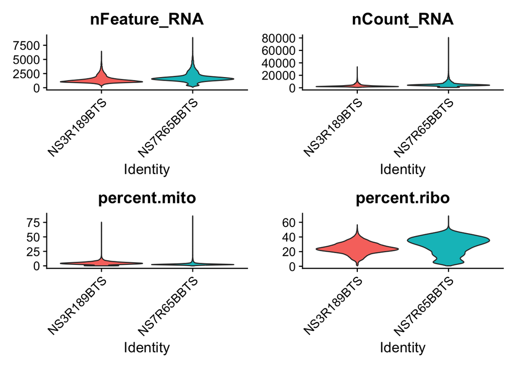

```r
# Generate before filtering quality plots
qcbefore=VlnPlot(allsamples,features = c("nFeature_RNA", "nCount_RNA","percent.mito","percent.ribo"),ncol = 2, pt.size = 0) +
  NoLegend()
qcbefore
```

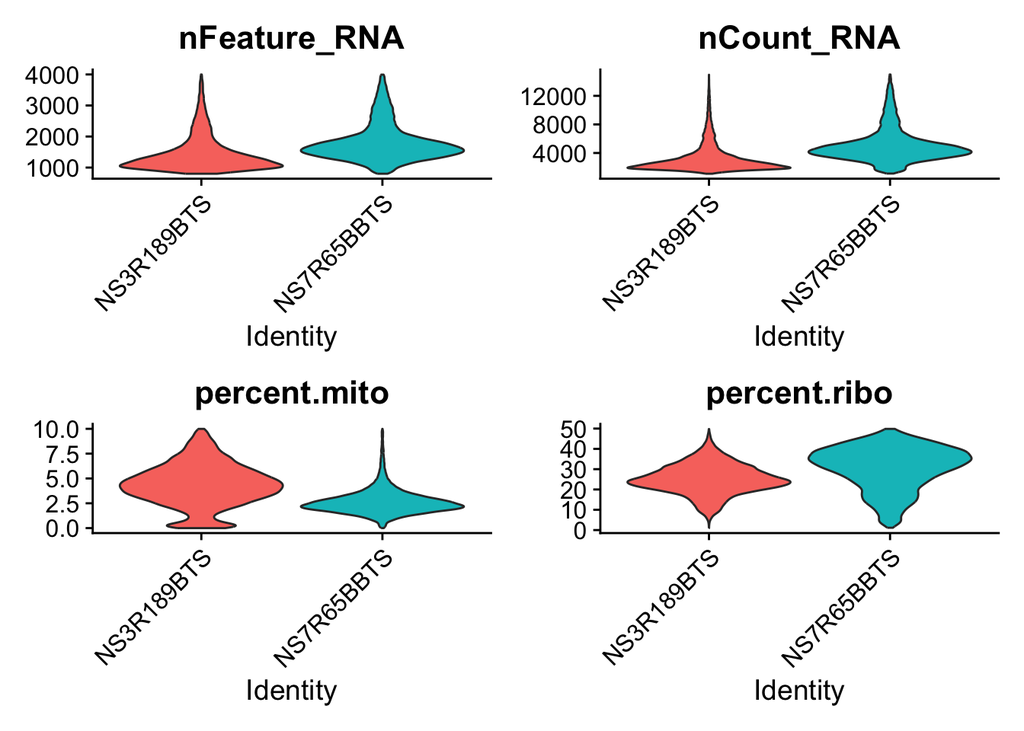

```r
# Save the plot in current working directory
ggsave(paste(outputpath,"before-qc-violineplot.pdf",sep=""), plot = qcbefore, width = 15, height = 20, units = "cm")

# Generate after filtering quality plots
qcafter=VlnPlot(allsamplesgood,features = c("nFeature_RNA", "nCount_RNA","percent.mito","percent.ribo"),ncol = 2, pt.size = 0) +
  NoLegend()
qcafter
```

```r
# Save the plot in current working directory
ggsave(paste(outputpath,"after-qc-violineplot.pdf",sep=""), plot = qcafter, width = 15, height = 20, units = "cm")
```